# Modeling Task 1 Report

Yash Gupta

April 11, 2025

# **Introduction**

In the Modeling Task 1, I have been provided with U.S. Economical Quarterly Data (1950Q1 - 2000Q4) comprising of key macro-economical variables such as gdp, consumption, disposable personal income, unemployment rate etc. The primary goal was to verify if changes in people’s income (DPI) and unemployment rates can explain changes in how much they spend (consumption). I have done the following tasks in the order as mentioned below :

1. **Verification of the specified linear model and evaluation of model accuracy**
2. **Outlier detection using Tukey’s test**
3. **Impact analysis of doubling the dataset**
4. **Autocorrelation check using Durbin-Watson test**

# **Task 1: Verification of Specified Linear Model**

## **Model Specification**

The regression model is specified as:
$$\Delta \text{Consumption}_t = \alpha + \beta_1 \Delta \text{DPI}_t +
\beta_2 \Delta \text{Unemp}_t + \epsilon_t$$

## **Data Preparation**

First differences were calculated for:  
- Consumption ($\Delta \text{Consumption}_t = \text{Consumption}_t - \text{Consumption}_{t-1}$)  
- Disposable income ($\Delta \text{DPI}_t$)  
- Unemployment rate ($\Delta \text{Unemp}_t$)

```r
df <- read.csv('data/ModelingTask1.csv', na.strings = 'NA')

df_diff <- df |>
  mutate(
    D_consumption = c(NA, diff(consumption)),
    D_dpi = c(NA, diff(dpi)),
    D_unemp = c(NA, diff(unemp))
  ) |>
  filter(!is.na(D_consumption))
```

Note : Only 1 row was removed due to differencing operation.

## **Results**

```r
model <- lm(D_consumption ~ D_dpi + D_unemp, data = df_diff)
summary_model <- summary(model)

knitr::kable(coef(summary_model), digits = 4,
             caption = "Linear Model Output (Task 1)")
```

Linear Model Output (Task 1)

|  | Estimate | Std. Error | t value | Pr(>\|t\|) |
| --- | --- | --- | --- | --- |
| (Intercept) | 16.2848 | 1.9108 | 8.5223 | 0 |
| D_dpi | 0.3557 | 0.0478 | 7.4440 | 0 |
| D_unemp | -16.0149 | 3.7922 | -4.2232 | 0 |

## **Model Accuracy**

Since model was build on the whole data and any testing data was not provided so I checked the accuracy metrics for regression on the training data itself.

```r
# Calculating R-squared, RMSE, MAE
rsq <- summary_model$r.squared
residuals <- residuals(model)
rmse <- sqrt(mean(residuals^2))
mae <- mean(abs(residuals))
```

```
## Accuracy Metrics:
##  R-squared: 0.335
##  RMSE: 20.19
##  MAE: 15.1
```

# **Task 2 : Outlier Detection using Tukey’s Test**

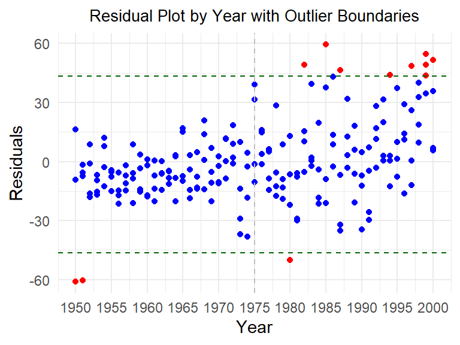

```r
years <- as.numeric(substr(df_diff$date, 1, 4))
iqr <- IQR(residuals)
lower_bound <- quantile(residuals, 0.25) - 1.5 * iqr
upper_bound <- quantile(residuals, 0.75) + 1.5 * iqr
outliers <- which(residuals < lower_bound | residuals > upper_bound)

ggplot(data.frame(Year = years, Residuals = residuals),
       aes(Year, Residuals)) +
  geom_point(color = ifelse(1:length(residuals) %in% outliers, "red", "blue")) +
  geom_hline(yintercept = c(lower_bound, upper_bound),
             linetype = "dashed", color = "darkgreen") +
  geom_vline(xintercept = 1975, color = "grey", linetype = "dashed") +
  scale_x_continuous(breaks = seq(1950, 2000, by = 5)) +
  labs(title = "Residual Plot by Year with Outlier Boundaries",
       x = "Year",
       y = "Residuals") +
  theme_minimal() +
  theme(plot.title = element_text(size = 10, hjust = 0.5))
```

## **Findings**:

- Number of outliers: 12.
- R² (0.335) and RMSE (20.19) may improve if outliers are addressed.
- If one closely observe there is significant change in variablity of residuals after near 1975, I analyzed it further and and fit different regression model for pre and post 1975 period.

## **Pre-1975 and Post-1975 Regression Models**:

```r
pre_1975 <- lm(D_consumption ~ D_dpi + D_unemp,
               data = subset(df_diff, as.numeric(substr(date, 1, 4)) <= 1975))
post_1975 <- lm(D_consumption ~ D_dpi + D_unemp,
                data = subset(df_diff, as.numeric(substr(date, 1, 4)) > 1975))
stargazer::stargazer(pre_1975, post_1975,
                     title = "Regression Results: Pre-1975 vs. Post-1975",
                     column.labels = c("Pre-1975", "Post-1975"),
                     type = "text")
```

```
##
## Regression Results: Pre-1975 vs. Post-1975
## ==================================================================
##                                  Dependent variable:
##                     ----------------------------------------------
##                                     D_consumption
##                            Pre-1975               Post-1975
##                               (1)                    (2)
## ------------------------------------------------------------------
## D_dpi                      0.343***                0.249***
##                             (0.062)                (0.071)
##
## D_unemp                   -11.528***              -28.482***
##                             (3.158)                (8.434)
##
## Constant                   10.250***              25.870***
##                             (1.865)                (3.280)
##
## ------------------------------------------------------------------
## Observations                  103                    100
## R2                           0.358                  0.293
## Adjusted R2                  0.346                  0.279
## Residual Std. Error    14.575 (df = 100)       22.998 (df = 97)
## F Statistic         27.942*** (df = 2; 100) 20.110*** (df = 2; 97)
## ==================================================================
## Note:                                  *p<0.1; **p<0.05; ***p<0.01
```

## **Extra Findings**:

- The negative effect of unemployment on consumption has more than doubled after 1975.
- Income’s impact on consumption has decreased by 28% post-1975.
- Prediction errors have risen by 58%, indicating greater variability after 1975.

# **Task 3: Doubled Data Analysis**

```r
doubled_data <- rbind(df_diff, df_diff)
model_doubled <- lm(D_consumption ~ D_dpi + D_unemp, data = doubled_data)
model <- lm(D_consumption ~ D_dpi + D_unemp, data = df_diff)
summary_model <- summary(model)
summary_model_doubled <- summary(model_doubled)
knitr::kable(coef(summary_model_doubled), digits = 4,
             caption = "Regression Coefficients (Task 3)")
```

Regression Coefficients (Task 3)

|  | Estimate | Std. Error | t value | Pr(>\|t\|) |
| --- | --- | --- | --- | --- |
| (Intercept) | 16.2848 | 1.3461 | 12.0975 | 0 |
| D_dpi | 0.3557 | 0.0337 | 10.5668 | 0 |
| D_unemp | -16.0149 | 2.6715 | -5.9948 | 0 |

```r
knitr::kable(
  data.frame(
    Original_SE = summary_model$coefficients[,2],
    Doubled_SE = summary(model_doubled)$coefficients[,2]
  ),
  caption = "Standard Error Comparison"
)
```

Standard Error Comparison

|  | Original_SE | Doubled_SE |
| --- | --- | --- |
| (Intercept) | 1.910841 | 1.3461302 |
| D_dpi | 0.047779 | 0.0336589 |
| D_unemp | 3.792157 | 2.6714606 |

## **Findings**:

- The model estimates **remained unchanged** after doubling the dataset.
- **Standard errors decreased by a factor of** $\sqrt{2}$, which leads to **inflated t-statistics**, creating **false confidence** in the estimates.

# Task 4: Autocorrelation Analysis

```r
model <- lm(D_consumption ~ D_dpi + D_unemp, data = df_diff)
residuals <- residuals(model)
n <- length(residuals)
numerator <- sum(diff(residuals)^2)
denominator <- sum(residuals^2)
dw_stat <- numerator/denominator
cat("Durbin-Watson Test Statistics: ", dw_stat )
```

```
## Durbin-Watson Test Statistics:  1.767096
```

```r
dwtest(model)
```

```
##
##  Durbin-Watson test
##
## data:  model
## DW = 1.7671, p-value = 0.04353
## alternative hypothesis: true autocorrelation is greater than 0
```

```r
cat("Successfully rejects the Null Hypthohesis at 0.05 level of significance.")
```

```
## Successfully rejects the Null Hypthohesis at 0.05 level of significance.
```

**Durbin-Watson Results**:

- There is positive auto-correlation which voilates the assumption of independent samples in linear regression model.
- We can also verify this using ACF Plot which shows that at for lag 2 and 3 there is significant positive auto-correlation.

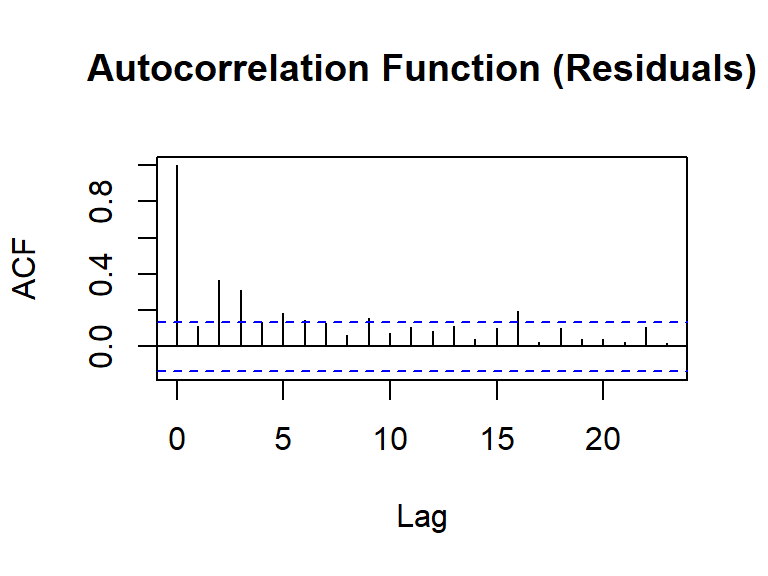

```r
acf(residuals, main = "Autocorrelation Function (Residuals)")
```

# **Conclusion**

This analysis of macroeconomic consumption dynamics provides key insights into the relationships between disposable income, unemployment, and consumption. Key takeaways include:

- The regression model indicates that **changes in DPI and unemployment** are significant predictors of consumption changes, but the model only explains a portion of the variation. Further predictors could be added to improve model accuracy.
- Outlier detection revealed some issues with residuals, especially around the 1975 period, where variability in consumption changes increased.
- Doubling the dataset did not change model estimates but led to **inflated t-statistics**, which suggests overconfidence in the estimates due to reduced standard errors.
- Autocorrelation in residuals was assessed using the Durbin-Watson test, which showed significant positive autocorrelation, indicating that model assumption of independent observations does not hold.

Overall, these findings highlight important trends and offer avenues for further research, such as investigating additional economic variables or extending the analysis to other time periods or datasets.